# Reporte Técnico de Accidentalidad en Medellín

# Introducción

El presente trabajo es un reporte técnico sobre la predicción de incidentes viales en la Ciudad de Medellin a partir de datos históricos de accidentes reportados por la Secretaría de Movilidad de la Alcaldía de Medellín cuya fecha de publicación fue el 28 de Diciembre del 2012 y su última modificación el 06 de Marzo del 2021. De acuerdo a la Organización Mundial de la Salud, al año se presenta la pérdida de más de 1,5 millones de vidas en siniestros viales, estos se han convertido en una problemática social por el daño que producen no solo en las familias sino también en la comunidad. En el caso de la ciudad de Medellín, según cifras de la Alcaldía de Medellín y la Secretaría de Movilidad, entre los años 2014 y 2020 se presentaron aproximadamente más de 200.000 incidentes viales.

El análisis predictivo agrupa una variedad de técnicas estadísticas de modelización, aprendizaje automático y minería de datos que analiza los datos actuales e históricos reales para hacer predicciones acerca del futuro o acontecimientos no conocidos, con este trabajo pretendemos aportar a la prevención de accidentes dre tránsito en la Ciudad, implementado un modelo que permitan predecir los incidentes viales en la Ciudad de Medellín que puedan ocurrir en determinado día, semana o mes, el cual puede ser utilizado por los organismos encargados de desarrollar planes y estrategias para prevenir acidentes, para el caso de Medellin la Secretaria de Movilidad .

# Exploración base de datos

En primer lugar, preparamos la base de datos para obtener buenos resultados a la hora de implementar los modelos. Al explorar la base de datos se encontraron algunos errores de digitación los cuales fueron debidamente corregidos, también se creó una nueva base de datos a partir de la publicada en MEdata con las variables que consideramos más pertinentes para el desarrollo del modelo. Encontramos en las observaciones de la variable Barrio que 18395 accidentes registrados se ubican en el municipio de Heliconia y por ende no corresponden a la ciudad de Medellín, debido a esto decidimos eliminar esos datos y también aquellos registros faltantes de información en las variables Barrio, Comuna y Localización.Cabe resaltar que con esa base de datos de 251189 observaciones se hizo el análisis descriptivo, pero para el modelo modificamos esa base y se eliminaron los registros de la columna BARRIO que presentaban números y no nombres, ya nuestro mapa no graficaba esos puntos y por falta de tiempo no nos fue posible imputar dichas observaciones.

| FECHA_ACCIDENTE | AÑO | CLASE_ACCIDENTE | GRAVEDAD_ACCIDENTE | MES | BARRIO | COMUNA | LOCATION | holi_bin |
| --- | --- | --- | --- | --- | --- | --- | --- | --- |
| 2014-07-04 | 2014 | Choque | Solo daños | 7 | La Floresta | La América | [-75.6025840302, 6.25428002686] | 0 |
| 2014-07-04 | 2014 | Choque | Solo daños | 7 | Calle Nueva | La Candelaria | [-75.5732039534, 6.23843689866] | 0 |
| 2014-07-04 | 2014 | Choque | Solo daños | 7 | Guayabal | Guayabal | [-75.5899249145, 6.1970468547] | 0 |
| 2014-07-04 | 2014 | Choque | Solo daños | 7 | Laureles | Laureles Estadio | [-75.595653992, 6.24537232424] | 0 |
| 2014-07-04 | 2014 | Choque | Solo daños | 7 | Parque Juan Pablo II | Guayabal | [-75.5920043504, 6.22222946966] | 0 |
| 2014-07-04 | 2014 | Choque | Solo daños | 7 | La Candelaria | La Candelaria | [-75.5676766589, 6.25277718802] | 0 |
| 2014-07-04 | 2014 | Choque | Solo daños | 7 | El Rincón | Belén | [-75.6043865284, 6.21056733572] | 0 |
| 2014-07-04 | 2014 | Choque | Solo daños | 7 | El Poblado | El Poblado | [-75.5673631561, 6.20947043279] | 0 |
| 2014-07-04 | 2014 | Choque | Solo daños | 7 | San Germán | Robledo | [-75.587217576, 6.26538815378] | 0 |
| 2014-07-04 | 2014 | Choque | Solo daños | 7 | Estación Villa | La Candelaria | [-75.56649243, 6.25602594722] | 0 |
| 2014-07-04 | 2014 | Choque | Solo daños | 7 | Laureles | Laureles Estadio | [-75.5940483665, 6.23901368312] | 0 |
| 2014-07-04 | 2014 | Choque | Solo daños | 7 | Calle Nueva | La Candelaria | [-75.5755026696, 6.2399699888] | 0 |
| 2014-07-04 | 2014 | Choque | Solo daños | 7 | San Bernardo | Belén | [-75.5976802402, 6.22272063984] | 0 |
| 2014-07-04 | 2014 | Choque | Solo daños | 7 | Corazón de Jesús | La Candelaria | [-75.5797413258, 6.24835603336] | 0 |
| 2014-07-04 | 2014 | Choque | Solo daños | 7 | Facultad de Minas U. Nacional | Robledo | [-75.5923497685, 6.27292496093] | 0 |
| 2014-07-04 | 2014 | Choque | Solo daños | 7 | San Diego | La Candelaria | [-75.5702052616, 6.23450856533] | 0 |
| 2014-07-04 | 2014 | Choque | Solo daños | 7 | Universidad Nacional | Robledo | [-75.5742557669, 6.26105610822] | 0 |
| 2014-07-04 | 2014 | Choque | Solo daños | 7 | Santa María de los Ángeles | El Poblado | [-75.5802751816, 6.19027119431] | 0 |
| 2014-07-04 | 2014 | Choque | Solo daños | 7 | La Candelaria | La Candelaria | [-75.5638204098, 6.24541448237] | 0 |
| 2014-07-04 | 2014 | Choque | Solo daños | 7 | Guayaquil | La Candelaria | [-75.570803628, 6.24471990473] | 0 |
| 2014-07-04 | 2014 | Choque | Solo daños | 7 | Las Acacias | Laureles Estadio | [-75.6002561334, 6.2387860571] | 0 |
| 2014-07-04 | 2014 | Choque | Solo daños | 7 | Carlos E. Restrepo | Laureles Estadio | [-75.5770396779, 6.25542030573] | 0 |
| 2014-07-04 | 2014 | Choque | Con muertos | 7 | Terminal de Transporte | Castilla | [-75.5706311344, 6.27412557275] | 0 |
| 2014-07-05 | 2014 | Atropello | Con heridos | 7 | Campo Valdés No. 2 | Manrique | [-75.5540595368, 6.27367256312] | 0 |
| 2014-07-05 | 2014 | Caida Ocupante | Con heridos | 7 | Florida Nueva | Laureles Estadio | [-75.5935200698, 6.24974103368] | 0 |
| 2014-07-05 | 2014 | Atropello | Con heridos | 7 | Simón Bolívar | La América | [-75.6067773699, 6.24408561865] | 0 |
| 2014-07-05 | 2014 | Atropello | Con heridos | 7 | La Piñuela | Aranjuez | [-75.5570928264, 6.27916354508] | 0 |
| 2014-07-05 | 2014 | Choque | Solo daños | 7 | Manrique Central No. 1 | Aranjuez | [-75.5550574239, 6.2681845763] | 0 |
| 2014-07-05 | 2014 | Choque | Solo daños | 7 | Facultad de Minas U. Nacional | Robledo | [-75.591159582, 6.27236713766] | 0 |
| 2014-07-05 | 2014 | Otro | Con heridos | 7 | Robledo | Robledo | [-75.5960692039, 6.27546730687] | 0 |
| 2014-07-05 | 2014 | Choque | Con heridos | 7 | Héctor Abad Gómez | Castilla | [-75.5595315756, 6.29945161558] | 0 |
| 2014-07-05 | 2014 | Atropello | Con heridos | 7 | La América | La América | [-75.6052741462, 6.25081235956] | 0 |
| 2014-07-05 | 2014 | Choque | Solo daños | 7 | Terminal de Transporte | Castilla | [-75.573496302, 6.27627044541] | 0 |
| 2014-07-05 | 2014 | Choque | Solo daños | 7 | Patio Bonito | El Poblado | [-75.5787575768, 6.20395536321] | 0 |
| 2014-07-05 | 2014 | Atropello | Con heridos | 7 | La Esperanza No. 2 | Popular | [-75.5434285138, 6.28984334534] | 0 |
| 2014-07-05 | 2014 | Atropello | Con heridos | 7 | El Chagualo | La Candelaria | [-75.5733892852, 6.26033577296] | 0 |
| 2014-07-05 | 2014 | Otro | Con heridos | 7 | La América | La América | [-75.6039753736, 6.25064085688] | 0 |
| 2014-07-05 | 2014 | Atropello | Con heridos | 7 | Berlin | Aranjuez | [-75.5537758983, 6.28449030902] | 0 |
| 2014-07-05 | 2014 | Caida Ocupante | Con heridos | 7 | Cabecera San Antonio de Prado | Corregimiento de San Antonio de Prado | [-75.6593400289, 6.18300992282] | 0 |
| 2014-07-05 | 2014 | Atropello | Con heridos | 7 | El Diamante No. 2 | El Poblado | [-75.577680673, 6.18747445198] | 0 |
| 2014-07-05 | 2014 | Choque | Con heridos | 7 | Barrio Colón | La Candelaria | [-75.569629034, 6.24112059146] | 0 |
| 2014-07-05 | 2014 | Atropello | Con heridos | 7 | Campo Valdés No. 1 | Aranjuez | [-75.5574799961, 6.2769133869] | 0 |
| 2014-07-05 | 2014 | Atropello | Con heridos | 7 | Barrio de Jesús | Buenos Aires | [-75.5370220449, 6.23102772162] | 0 |
| 2014-07-05 | 2014 | Choque | Solo daños | 7 | Los Colores | Laureles Estadio | [-75.5963306991, 6.26518602759] | 0 |
| 2014-07-05 | 2014 | Choque | Solo daños | 7 | Belén | Belén | [-75.6041633678, 6.23183171238] | 0 |
| 2014-07-05 | 2014 | Choque | Solo daños | 7 | El Velódromo | Laureles Estadio | [-75.5959104224, 6.25792129904] | 0 |
| 2014-07-05 | 2014 | Caida Ocupante | Con heridos | 7 | Cerro Nutibara | Belén | [-75.5809657948, 6.23320774321] | 0 |
| 2014-07-05 | 2014 | Volcamiento | Con heridos | 7 | Robledo | Robledo | [-75.5953312711, 6.27488829713] | 0 |
| 2014-07-05 | 2014 | Choque | Solo daños | 7 | La Aguacatala | El Poblado | [-75.5755543051, 6.19851066363] | 0 |
| 2014-07-05 | 2014 | Choque | Solo daños | 7 | El Progreso | Castilla | [-75.5800542878, 6.2735251587] | 0 |

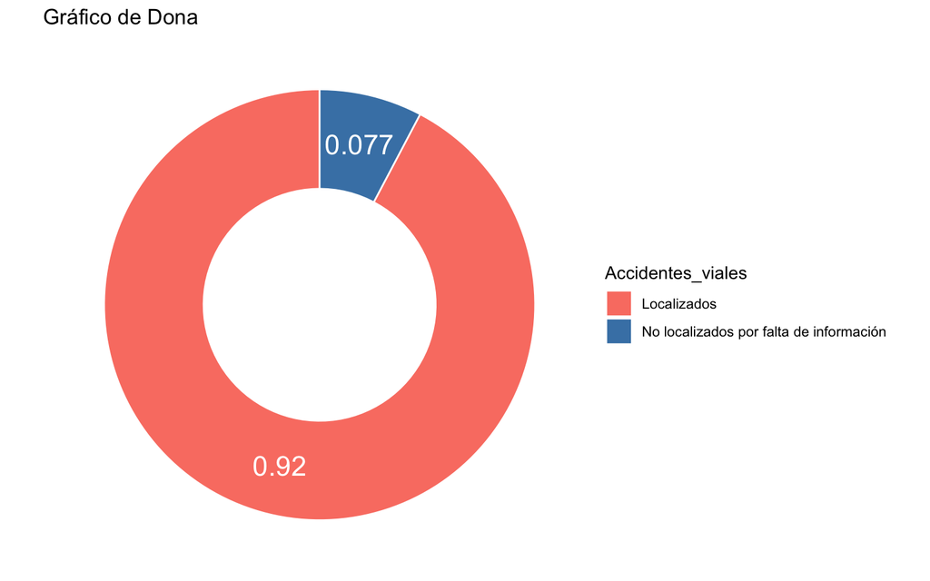

|  | 2014 | 2015 | 2016 | 2017 | 2018 | 2019 | 2020 |
| --- | --- | --- | --- | --- | --- | --- | --- |
| Con heridos | 11547 | 23600 | 24320 | 22952 | 20983 | 22997 | 11099 |
| Con muertos | 136 | 260 | 249 | 239 | 232 | 224 | 104 |
| Solo daños | 9131 | 18926 | 19041 | 19574 | 19066 | 19256 | 7253 |

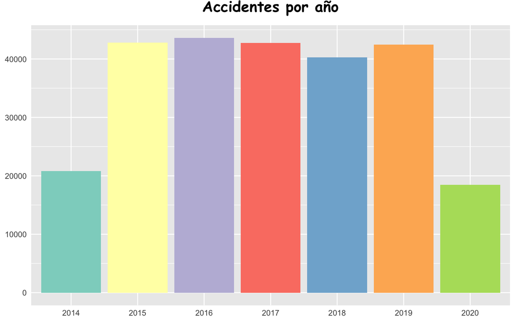

Con respecto a la frecuencia de accidentes registrados por mes entre 2014 y 2020 se puede observar que en el mes en que más se presentan incidentes viales es en Agosto, esto puede ser explicado porque en ese mes se lleva a cabo la Feria de Flores en la Ciudad de Medellin y por ende circulan más vehículos y peatones de lo normal. Asi mismo, podemos notar que el mes de abril es donde se han presentado menores accidentes.

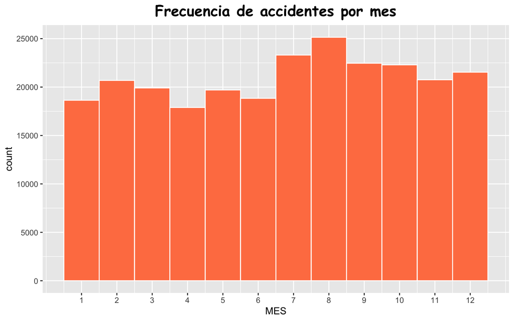

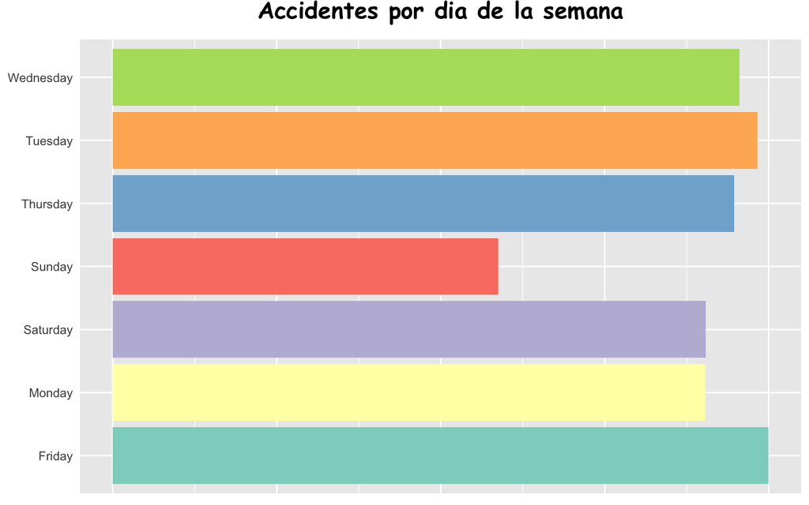

Este gráfico presenta la gravedad de los accidentes registrados entre el 2014 y el 2020, se puede deducir que en todos los años los accidentes registrados en su mayoria presentan heridos y solo daños en comparación con las muertes.

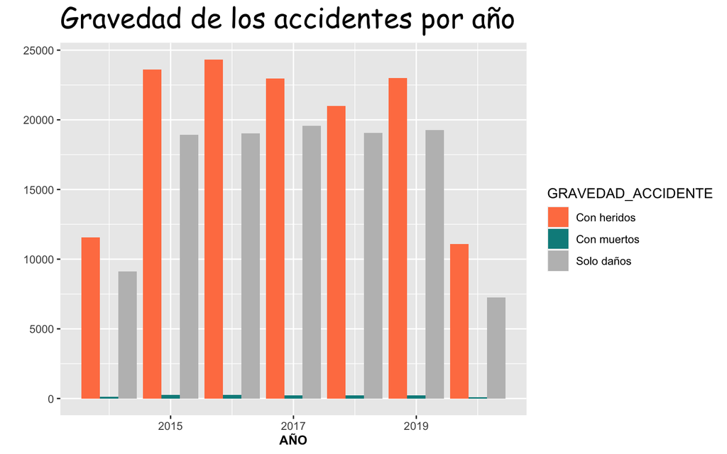

|  | 2014 | 2015 | 2016 | 2017 | 2018 | 2019 | 2020 |
| --- | --- | --- | --- | --- | --- | --- | --- |
| Atropello | 2376 | 4524 | 4185 | 3655 | 3581 | 3973 | 1771 |
| Caida Ocupante | 2059 | 3741 | 3734 | 3459 | 3615 | 3522 | 1481 |
| Choque | 13583 | 28761 | 29212 | 29317 | 28170 | 28843 | 11729 |
| Incendio | 4 | 1 | 4 | 4 | 7 | 8 | 0 |
| Otro | 2309 | 4294 | 4960 | 4744 | 3735 | 4519 | 2221 |
| Volcamiento | 483 | 1465 | 1515 | 1586 | 1173 | 1612 | 1254 |

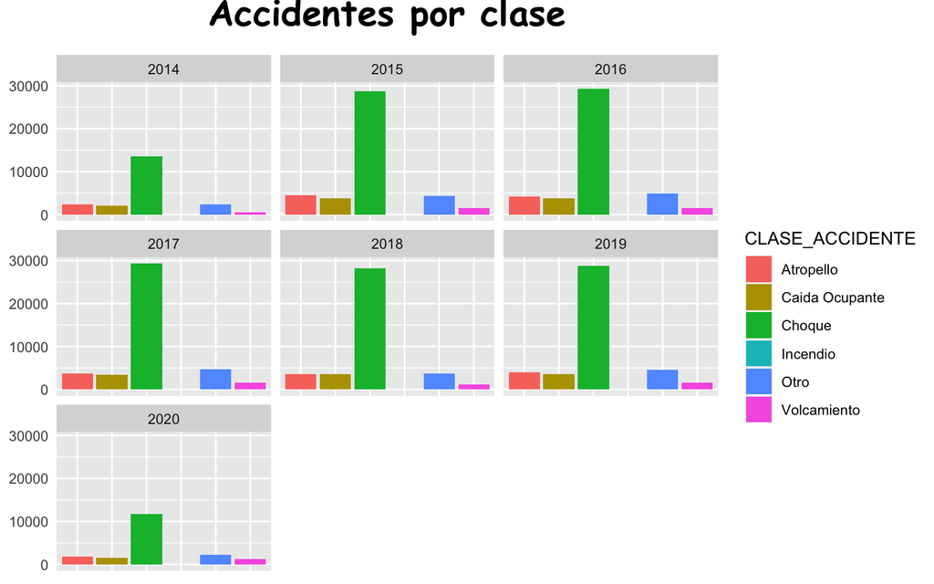

|  | Atropello | Caida Ocupante | Choque | Incendio | Otro | Volcamiento |
| --- | --- | --- | --- | --- | --- | --- |
| Con heridos | 23383 | 21541 | 57287 | 12 | 26421 | 8854 |
| Con muertos | 682 | 70 | 675 | 1 | 10 | 6 |
| Solo daños | 0 | 0 | 111653 | 15 | 351 | 228 |

[figure not shown]

| Barrio | Cantidad_accidentes |
| --- | --- |
| La Candelaria | 5901 |
| Campo Amor | 5142 |
| Caribe | 5093 |
| Perpetuo Socorro | 4858 |
| Colon | 4489 |
| Santa fe | 4108 |
| Cabecera San Antonio de Prado | 3986 |
| Conquistadores | 3767 |
| Villa Nueva | 3726 |
| San Benito | 3538 |

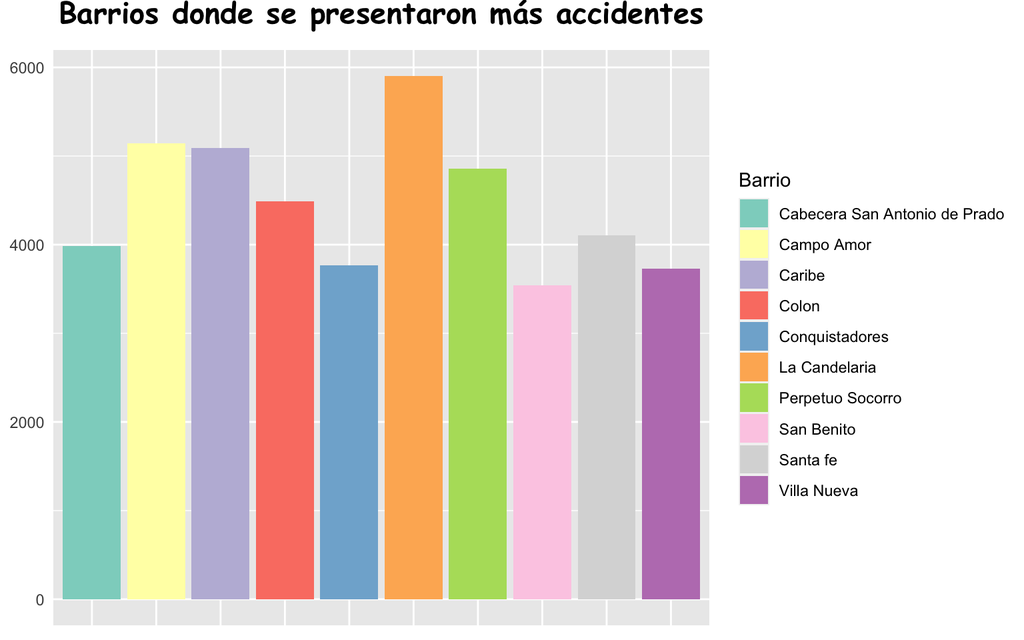

# Base de datos transformada

Se realiza un conteo de accidentes por día agrupando por la variable barrio y tipo de accidente

```r
conteos <- datos %>% group_by(FECHA_ACCIDENTE, CLASE_ACCIDENTE=as.factor(CLASE_ACCIDENTE),
                              BARRIO= as.factor(BARRIO), COMUNA= as.factor(COMUNA))%>%count() %>%data.frame()
```

Se añaden algunas variables de intéres como

```r
# Arreglando variables predictivas
holidays_fecha<-readRDS(file = "bases_datos/Holidays.rds") %>% data.frame()
conteos$dia_n <-  as.integer(format(conteos$FECHA_ACCIDENTE, "%d"))
conteos$dia <- as.factor(wday(conteos$FECHA_ACCIDENTE, label = TRUE))
conteos$mes <- as.factor(format(conteos$FECHA_ACCIDENTE, "%b"))
conteos$ano <- as.integer(format(conteos$FECHA_ACCIDENTE, "%Y"))
conteos$holi_bin <- ifelse(conteos$FECHA_ACCIDENTE %in% holidays_fecha$holidays_fecha , 1, 0) %>% factor()
conteos$BARRIO<- as.factor(conteos$BARRIO)
```

Teniendo la base de datos la siguiente estructura:

| FECHA_ACCIDENTE | CLASE_ACCIDENTE | BARRIO | COMUNA | n | dia_n | dia | mes | ano | holi_bin |
| --- | --- | --- | --- | --- | --- | --- | --- | --- | --- |
| 2014-07-04 | choque | calle nueva | la candelaria | 2 | 4 | Fri | Jul | 2014 | 0 |
| 2014-07-04 | choque | carlos e. restrepo | laureles estadio | 1 | 4 | Fri | Jul | 2014 | 0 |
| 2014-07-04 | choque | corazon de jesus | la candelaria | 1 | 4 | Fri | Jul | 2014 | 0 |
| 2014-07-04 | choque | el poblado | el poblado | 1 | 4 | Fri | Jul | 2014 | 0 |
| 2014-07-04 | choque | el rincon | belen | 1 | 4 | Fri | Jul | 2014 | 0 |
| 2014-07-04 | choque | estacion villa | la candelaria | 1 | 4 | Fri | Jul | 2014 | 0 |
| 2014-07-04 | choque | facultad de minas u. nacional | robledo | 1 | 4 | Fri | Jul | 2014 | 0 |
| 2014-07-04 | choque | guayabal | guayabal | 1 | 4 | Fri | Jul | 2014 | 0 |
| 2014-07-04 | choque | guayaquil | la candelaria | 1 | 4 | Fri | Jul | 2014 | 0 |
| 2014-07-04 | choque | la candelaria | la candelaria | 2 | 4 | Fri | Jul | 2014 | 0 |
| 2014-07-04 | choque | la floresta | la america | 1 | 4 | Fri | Jul | 2014 | 0 |
| 2014-07-04 | choque | las acacias | laureles estadio | 1 | 4 | Fri | Jul | 2014 | 0 |
| 2014-07-04 | choque | laureles | laureles estadio | 2 | 4 | Fri | Jul | 2014 | 0 |
| 2014-07-04 | choque | parque juan pablo ii | guayabal | 1 | 4 | Fri | Jul | 2014 | 0 |
| 2014-07-04 | choque | san bernardo | belen | 1 | 4 | Fri | Jul | 2014 | 0 |
| 2014-07-04 | choque | san diego | la candelaria | 1 | 4 | Fri | Jul | 2014 | 0 |
| 2014-07-04 | choque | san german | robledo | 1 | 4 | Fri | Jul | 2014 | 0 |
| 2014-07-04 | choque | santa maria de los angeles | el poblado | 1 | 4 | Fri | Jul | 2014 | 0 |
| 2014-07-04 | choque | terminal de transporte | castilla | 1 | 4 | Fri | Jul | 2014 | 0 |
| 2014-07-04 | choque | universidad nacional | robledo | 1 | 4 | Fri | Jul | 2014 | 0 |
| 2014-07-05 | atropello | barrio de jesus | buenos aires | 1 | 5 | Sat | Jul | 2014 | 0 |
| 2014-07-05 | atropello | berlin | aranjuez | 1 | 5 | Sat | Jul | 2014 | 0 |
| 2014-07-05 | atropello | betania | san javier | 1 | 5 | Sat | Jul | 2014 | 0 |
| 2014-07-05 | atropello | campo valdes no. 1 | aranjuez | 2 | 5 | Sat | Jul | 2014 | 0 |
| 2014-07-05 | atropello | campo valdes no. 2 | manrique | 2 | 5 | Sat | Jul | 2014 | 0 |
| 2014-07-05 | atropello | doce de octubre no.2 | doce de octubre | 1 | 5 | Sat | Jul | 2014 | 0 |
| 2014-07-05 | atropello | el chagualo | la candelaria | 1 | 5 | Sat | Jul | 2014 | 0 |
| 2014-07-05 | atropello | el diamante no. 2 | el poblado | 1 | 5 | Sat | Jul | 2014 | 0 |
| 2014-07-05 | atropello | el pinal | villa hermosa | 1 | 5 | Sat | Jul | 2014 | 0 |
| 2014-07-05 | atropello | el poblado | el poblado | 1 | 5 | Sat | Jul | 2014 | 0 |
| 2014-07-05 | atropello | la america | la america | 1 | 5 | Sat | Jul | 2014 | 0 |
| 2014-07-05 | atropello | la candelaria | la candelaria | 2 | 5 | Sat | Jul | 2014 | 0 |
| 2014-07-05 | atropello | la cruz | manrique | 1 | 5 | Sat | Jul | 2014 | 0 |
| 2014-07-05 | atropello | la esperanza no. 2 | popular | 1 | 5 | Sat | Jul | 2014 | 0 |
| 2014-07-05 | atropello | la pinuela | aranjuez | 1 | 5 | Sat | Jul | 2014 | 0 |
| 2014-07-05 | atropello | las granjas | manrique | 1 | 5 | Sat | Jul | 2014 | 0 |
| 2014-07-05 | atropello | manrique oriental | manrique | 1 | 5 | Sat | Jul | 2014 | 0 |
| 2014-07-05 | atropello | miraflores | buenos aires | 1 | 5 | Sat | Jul | 2014 | 0 |
| 2014-07-05 | atropello | simon bolivar | la america | 1 | 5 | Sat | Jul | 2014 | 0 |
| 2014-07-05 | atropello | sucre | villa hermosa | 1 | 5 | Sat | Jul | 2014 | 0 |
| 2014-07-05 | atropello | terminal de transporte | castilla | 1 | 5 | Sat | Jul | 2014 | 0 |
| 2014-07-05 | atropello | villa guadalupe | popular | 1 | 5 | Sat | Jul | 2014 | 0 |
| 2014-07-05 | caida ocupante | belen | belen | 1 | 5 | Sat | Jul | 2014 | 0 |
| 2014-07-05 | caida ocupante | cabecera san antonio de prado | corregimiento de san antonio de prado | 1 | 5 | Sat | Jul | 2014 | 0 |
| 2014-07-05 | caida ocupante | calle nueva | la candelaria | 1 | 5 | Sat | Jul | 2014 | 0 |
| 2014-07-05 | caida ocupante | campo amor | guayabal | 1 | 5 | Sat | Jul | 2014 | 0 |
| 2014-07-05 | caida ocupante | cerro nutibara | belen | 1 | 5 | Sat | Jul | 2014 | 0 |
| 2014-07-05 | caida ocupante | doce de octubre no.1 | doce de octubre | 2 | 5 | Sat | Jul | 2014 | 0 |
| 2014-07-05 | caida ocupante | el pinal | villa hermosa | 1 | 5 | Sat | Jul | 2014 | 0 |
| 2014-07-05 | caida ocupante | el progreso | castilla | 1 | 5 | Sat | Jul | 2014 | 0 |

- FECHA_ACCIDENTE: Fecha en la que ocurrió el accidente , el formato es AÑO-MES-DIA
- MES: Mes en que se presentó el accidente,la variable está enumerada del 1 al 12, comenzando desde enero
- AÑO: Año en el que se registró el accidente
- BARRIO:Lugar de Medellin donde se presentó el accidente, tipo factor con 321 niveles
- CLASE_ACCIDENTE: Los accidentes se clasifican en atropello, choque,incendio,volcamiento,caída de ocupante y otros
- GRAVEDAD: Gavedad del acidente(Solo daños, con heridos, con muertos
- holi_bin: Días especiales como feria de flores y dias festivos en Colombia, tipo factor con 2 niveles, con 1 en caso de que sea una fecha festiva y 0 en caso contrario
- COMUNA: Nombre de las comunas de Medellín, tipo factor con 29 niveles

Según la base de datos el año donde se presentaron más accidentes fue el 2016 en comparación con los demás años, a pesar de que solo tenemos datos para el 2020 hasta el mes de junio se puede plantear que los accidentes en ese año hasta junio disminuyeron con respecto a los demás años esto puede ser a raíz del confinamiento por la pandemia.

# División datos

```r
setwd("/Users/andremac/Downloads/Tae-AccidentalidadMed")
train<- readRDS("bases_datos/train.rds")
validation <- conteos %>% filter(ano >= 2018 | ano <= 2019)
test <- conteos  %>% filter(ano >= 2020)
```

# Modelo

En este caso se ha elegido modelo lineal generalizado (glm) el cual busca predecir la accidentalidad por tipo de accidente a nivel semanal, mensual y diario. La función de enlace utilizada ha sido la distribución de Poisson ya que se utiliza para modelar la variación en los datos de recuento (es decir, datos que pueden ser iguales a 0, 1, 2,…). La variable respuesta $y_i$ sería el número de accidentes de tráfico en el barrio i en un intervalo de tiempo determinado. Se propone explicar la variación en $y_i$ con predictores lineales X, Con un total de 346 coeficientes entre barrios, fechas especiales, número del día, día de la semana, el mes y el año.

$$y_{i} \sim \operatorname{Poisson}\left(\exp \left( 0.5013+ 0.4033*mesAug+...-1.135e^{-05}*BARRIOyolombo\right)\right)$$

```r
fit.1 <- glm (n ~ ano + mes + dia_n + dia + holi_bin+CLASE_ACCIDENTE+BARRIO+FECHA_ACCIDENTE,
              family=poisson(link = log),data = train)
```

[output not shown]

```r
y_est1<- predict.glm(object = fit.1, newdata = train[,-5], type = "response")
y_est2<-predict(object = fit.1, newdata=test[,-5], , type = "response")
y_est3<-predict(object = fit.1, newdata=validation[,-5], type = "response" )
mean((train$n - y_est1)^2)
```

```
## [1] 0.337826
```

```r
mean((test$n - y_est2)^2)
```

```
## [1] 1.413125
```

```r
mean((validation$n - y_est3)^2)
```

```
## [1] 1.357081
```

$$\mathrm{MSE_{train}}=\frac{1}{N} \sum_{i=1}^{N}\left(y_{i}-\hat{y}_{i}\right)^{2} = 0.337826$$

# Código

Se pueden consultar lo respectivos códigos utilizados para llevar a cabo los resultados desarrollados en el presente informe técnico sobre accidentalidad en la ciudad de Medellín en el siguiente repositorio de github https://github.com/kaamayam/Tae-AccidentalidadMed